# Project Group 25

Members: Tomas Bisschop (5363527), Kuba Samorek (5664012), Jorben van der Sar (5382513), Yusuf Dalli (6048501), Saskia Veldkamp (6060846)

## 1. Introduction

In 2003, drivers of specific vehicle types had to pay a few British pounds to enter the centre of London during specific hours. The goal of this charge was to reduce the vehicular activities in the centre of London. Therefore, it is interesting to examine if the congestion charge is successful in achieving this goal. This leads to the following research question:

```
“How does the congestion charge in London impact the vehicular activities within the congestion charge zone?”
```

To answer this question, there will be a look into the numbers of different vehicle types and the amount of kilometres travelled by cars within the congestion charge zone. This leads to the following two subquestions:

```
1) "To what extent does the congestion charge in London affect the numbers of different vehicle types within the congestion charge zone?"
2) "To what extent does the congestion charge in London affect the travelled kilometres by cars within the congestion charge zone?"
```

The research for answering these questions spans from 2000 to 2021, encompassing the period before and after the introduction of the congestion charge in 2003. This approach allows an examination of the vehicular activities preceding the implementation of the charge and the periodically increase of the price of the charge over the years.

## 2. Background research and conceptualisation

The congestion charge in London was established at the beginning of 2003, requiring drivers to pay a specific fee to enter a designated area of London during certain weekday hours. Over the years, the price of the charge has progressively increased (Dunt, 2023), as illustrated in Table 1. The designated zone for this congestion charge encompasses Westminster, Lambeth, Southwark, City of London, Tower Hamlets, Islington and Camden (Tang, 2021).

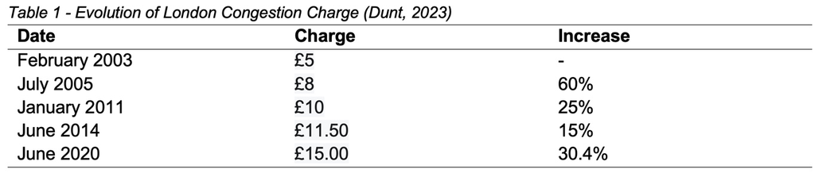

The vehicles for which the congestion charge in the centre London applies are cars, taxis, Large Goods Vehicles (LGV) and Heavy Goods Vehicles (HGV). The primary objective of this charge is thus to reduce the appeal of these vehicle types, and to increase the appeal of two-wheeled motor vehicles, buses, coaches and pedal cycles (Beevers & Carslaw, 2005). This is deemed essential in addressing traffic congestion, improving air quality, combating climate change, and reducing noise pollution in London (Leape, 2006).

Numerous studies have demonstrated that the implementation of a congestion charge has the potential to curtail both the number of vehicles for which the charge applies and the total distance travelled by vehicles for which the charge applies (Börjesson & Kristoffersson, 2015; Eliasson, 2008; Gibson & Carnovale, 2015; May & Milne, 2000; Seik, 2000). As such, the underlying hypothesis posits that with the introduction of the congestion charge in London in 2003 and the increase of the height of the charge over the years, there will be a gradual reduction over time in the number of cars, taxis, Light Good Vehicles and Heavy Good Vehicles. As a consequence of this, it is expected that the number of two-wheeled motor vehicles, buses, coaches and pedal cycles gradually increases in the congestion zone. Also, it is anticipated that the travelled distance by car in the congestion zone wil gradually decrease over the years. Finally, it is anticipated that the most substantial changes in both vehicle counts and kilometres travelled will be observed following the charge’s initiation in 2003 and its subsequent height increases in 2005, 2011, 2014 and 2020. The conceptual model is shown in Figure 1.

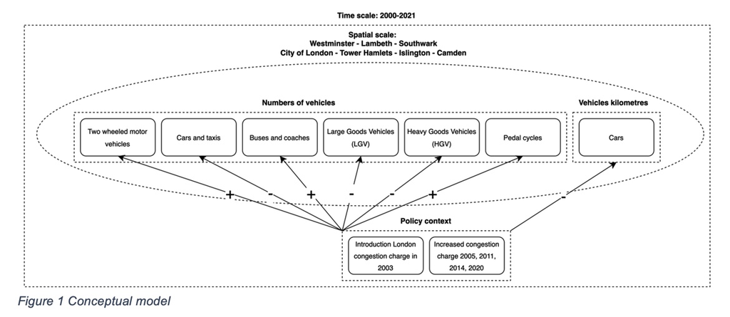

## 3. Brief overview of data used

This research makes use of data obtained from the Department of Transportation of United Kingdom in the form of CSV files for SQ1 and SQ2. The dataset for SQ1, spans over the years of 2000-2022, providing information about AADT and counts of Different Vehicle Types on set points. The data preprocessing steps involved setting year intervals for dates that the congestion zone price got changed, grouping cities and removing overlapping highways to achieve the congestion zone area and converting kilometres travelled to numerical values. The dataset for SQ2 spans from 1993-2021, providing information about the million kilometers travelled by car in London. The data preprocessing steps involved the extraction of local authorities within the congestion zone and the years 2000-2021, the converting of kilometres travelled to numerical values and the summed total kilometres for the specified local authorities.

## 4. Data pipeline

The data pipeline for subquestion 1 starts with import, where the pandas library is used to load the CSV files downloaded from the web. One of the challenges was that the data did not have the congestion zone area, therefore cities had to be manually identified and grouped, while doing that some cities had countpoints both inside and outside the congestion zone and we had to manually remove the roads containing countpoints that were outside the congestion zone in these cities. The data needed to be cleaned up of any potential commas and transformed to integer values for SQ2.

The data pipeline for subquestion 2 starts with import, where the pandas library is used to load the CSV file downloaded from the web. The libraries used for this subquestion are pandas and plotly express. The challenges and considerents were to make sure to convert values to numerical values and remove any possible commas.

## 5. To what extent does the congestion charge in London affect the numbers of different vehicle types within the congestion charge zone?

This section addresses subquestion 1, titled 'To what extent does the congestion charge in London affect the number of different vehicle types within the congestion charge zone?' To begin, the data source is outlined, followed by the process of data visualisation and analysis. Finally, the subquestion is answered.

### 5.1. Data source

To answer subquestion 1 road traffic statistics from the Department for Transport are consulted (Department for Transport, n.d.). These statistics consist of the numbers of different vehicle types inside London’s congestion charge area in the period 2000-2021. The data import and visualisation for subquestion 1 is presented in the Github repository named subquestion_1_data_import.ipynb.

### 5.2. Data visualisation and analysis

The introduction of the congestion charge zone in London can be associated with having a significant effect on the usage of vehicles in the area, as can be seen in the graph below. However, the shift did not affect all the drivers equally, and hence: all types of vehicles. Following section aims to answer the above subquestion and determine the main findings of this part of the research.

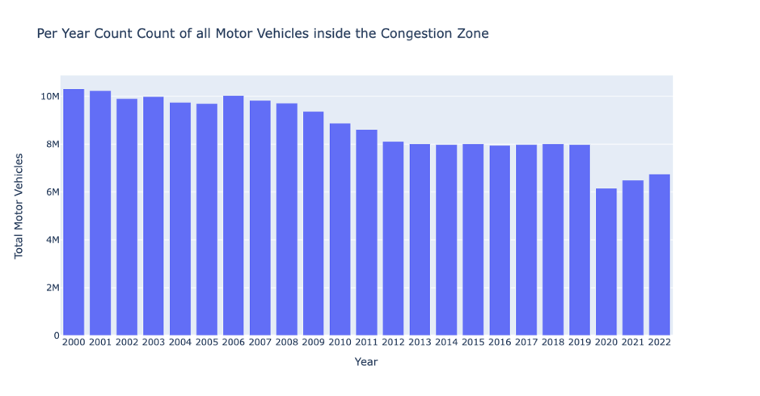

As seen on the graph below, the most substantial difference occurring throughout the years is the total use of cars - which almost halved within the two decades. Most important intakes obtained through the analysis of the data are as follows:

- Firstly, the usage of logistics-oriented vehicles (large goods vehicles and heavy goods vehicles) in the area remained at a stable, slightly decreased level, with a small increase in the number of LGVs and a decrease of approximately one third of HGVs. It is important to notice that the initial number of LGVs was multiple times higher than the number of HGVs in the zone.
- Secondly, we can observe a steady increase in the usage of pedal vehicles. The number of bikes in the congestion zone of the city of London nearly doubled, from approximately 300 thousand to 600 thousand. It is possible to speculate that the introduction of payments for driving within the zone had a positive effect on the biking habits of London’s inhabitants, given the novel obstacles associated with the use of motor vehicles.
- Thirdly, usage of two-wheeled motor vehicles and buses was not significantly affected by the introduction of the payment system. While the lack of change for buses, used by the public transport institutions, seems understandable, there is no particular reasoning that can be attributed to the lack of change in usage of two-wheeled motor vehicles.
- Lastly, the rate of change was gradual, seemingly not affected by the consecutive raises of rates for driving in the congestion zone. As seen on the graph below, the only outlier in terms of sudden reduction of vehicle usage happened between years 2019 and 2020, where we can observe a significant decrease for a few vehicle types (namely: cars, LGVs and two-wheeled motor vehicles). The idea is further supported by the count of all vehicles in the years 2019 and 2020, as seen in the according above graph. This sudden change however, can be attributed to the historical events taking place in those years, namely Covid-19 pandemic and state-wide lockdown. With that in mind, we can assume that the changes were gradual and organic, rather than parallel to the rise of charges for driving within the London congestion zone.

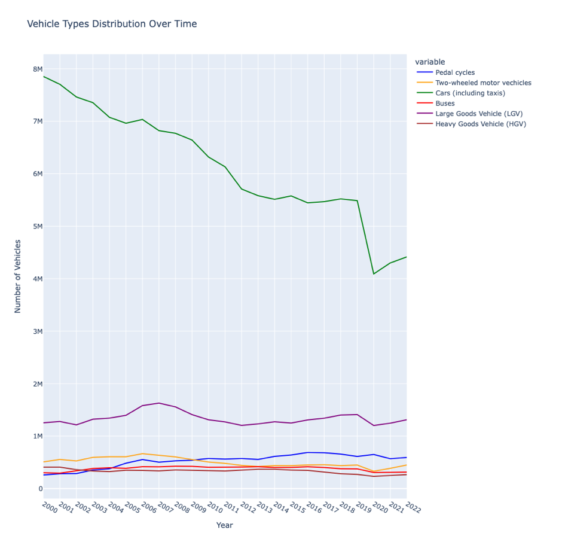

### 5.3. Answer subquestion 1

The outcome of this part of the research and the answer to the first subquestion clearly indicate that the initial hypothesis was partially correct. The introduction of a payment scheme for access to the congestion zone area influenced the overall vehicle count, by decreasing the total number of motor vehicles on the central streets of London. The observed result consists of a stable and gradual decrease over the studied period, rather than recurring, substantial decline (or significant change in gradient) every time a new fare was introduced. The only exception to the mentioned tendency were years 2019-2020, which can be linked to external effects of Covid-19 pandemic and related lockdown.

## 6. To what extent does the congestion charge in London affect the travelled kilometres by cars within the congestion charge zone?

This section addresses subquestion 2, titled 'To what extent does the congestion charge in London affect the travelled kilometers by cars within the congestion charge zone?' To begin, the data source is outlined, followed by the process of data visualisation and analysis. Finally, the subquestion is answered.

### 6.1. Data source

To answer subquestion 2, road flow statistics adapted from the National Road Traffic Survey by the Department for Transport are consulted (Greater London Authority, n.d.). These statistics consist of the million vehicle kilometres travelled by all cars inside London’s congestion charge area in the period 2000-2021. The data import and visualisation for subquestion 2 is presented in the Github repository named datavisualisation_subquestion2.ipynb

### 6.2. Data visualisation and analysis

The graph below illustrates the year-over-year changes in kilometers travelled by cars within the congestion zone from 2000 to 2021. It indicates a gradual decline in the kilometers travelled by car over these years except for the decrease in 2020. Consequently, it can be inferred that in general the congestion charge in London has an impact on the number of kilometers travelled by cars within the congestion zone.

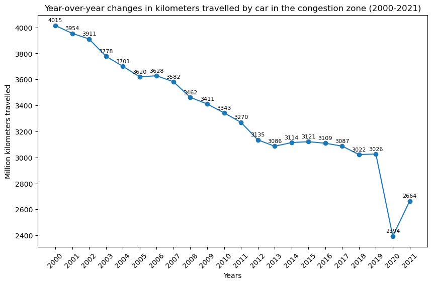

An analysis is conducted to better understand the extent to which the congestion charge impacts the travelled kilometers by cars within the congestion charge zone. This involves the calculation of the percentage change in the travelled kilometres by car compared with the previous year. The results of this analysis are presented in Table 2.

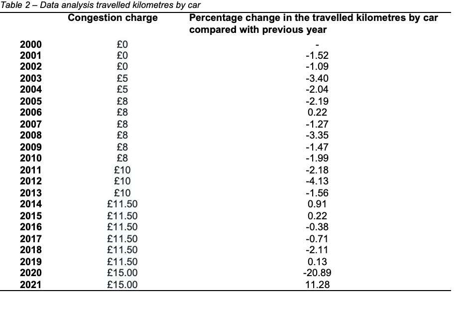

### 6.3. Answer subquestion 2

The initial hypothesis outlined in Section 2 is that there was a gradual reduction in travelled kilometres by car in the congestion charge zone since the congestion charge’s implementation in 2003 up to 2021. It was also anticipated that the most substantial changes in kilometres travelled would be in 2003, the year the charge was introduced, and 2005, 2011, 2014, and 2020, the years the price was increased. This section addresses whether the data supports or contradicts these initial assumptions.

As seen in the graph above, there is an overall downward trend in kilometres travelled by car from 2000 to 2021. This decrease in kilometres travelled started before the congestion charge was introduced in 2003. In this earlier period from 2000 to 2002, the average decrease of kilometres travelled was 1.31%. For the years after 2003, the average decrease is 1.84%. Years 2020 and 2021 differ greatly from the previous years and do not follow the same gradual trend; excluding these years from the average results in an average decrease of 1.49% which is still higher than the pre-2003 average.

Although kilometres travelled by car were decreasing before 2003, the average decrease is greater since the introduction of the congestion charge in 2003. This supports the initial hypothesis that there was a gradual reduction in travelled kilometres by car within the congestion charge zone in the years the congestion charge has been in place.

The second assumption was that the years when the congestion charge was raised would have the largest reductions in kilometres travelled by car. When looking at the graph alone, there is a slightly larger drop in kilometres travelled in some of the years corresponding to price increases.

Based on the percentage changes in Table 2, the years with the largest reductions in travelled kilometres are 2003, 2005, 2008, 2011, 2012, and 2020, all of which are years a price increase was introduced or the year directly after a price increase, with the exception of 2008. This exception may be explained by another factor outside of the congestion charge that can also affect travel behaviour. Regarding the second assumption, the data suggests that some of the most substantial changes in kilometres travelled did occur in years corresponding to price increases.

## 7. Conclusion

These findings suggest that the congestion charge has been successful in reducing traffic in the congestion charge zone. However, there are many factors that can affect travel behaviour that were not considered in this project. One example mentioned earlier is COVID-19 which is primarily responsible for the drop in traffic in 2020, but there may be other policies or circumstances influencing travel decisions in other years. While the congestion charge appears to correlate with decreased traffic, determining the exact impact of the congestion charge requires further research.

## 8. Sources

- Beevers, S., & Carslaw, D. C. (2005). The impact of congestion charging on vehicle emissions in London. Atmospheric Environment, 39(1), 1–5. https://doi.org/10.1016/j.atmosenv.2004.10.001
- Börjesson, M., & Kristoffersson, I. (2015). The Gothenburg congestion charge. Effects, design and politics. Transportation Research Part A: Policy and Practice, 75, 134–146. https://doi.org/10.1016/j.tra.2015.03.011
- Department for Transport. (n.d.). Road traffic statistics - London region. https://roadtraffic.dft.gov.uk/regions/6
- Dunt, I. (2023, March 30). London Congestion Charge - The History and Debate. Politics.co.uk. https://www.politics.co.uk/reference/congestion-charge/#:~:text=The%20first%20Mayor%20of%20London,%C2%A315%20from%20June%202020.
- Eliasson, J. (2008). Lessons from the Stockholm congestion charging trial. Transport Policy, 15(6), 395–404. https://doi.org/10.1016/j.tranpol.2008.12.004
- Gibson, M., & Carnovale, M. (2015). The effects of road pricing on driver behavior and air pollution. Journal of Urban Economics, 89, 62–73. https://doi.org/10.1016/j.jue.2015.06.005
- Greater London Authority. (n.d.). Traffic flows, borough – London Datastore. https://data.london.gov.uk/dataset/traffic-flows-borough
- Leape, J. (2006). The London congestion charge. Journal of Economic Perspectives, 20(4), 157–176. https://doi.org/10.1257/jep.20.4.157
- May, A. D., & Milne, D. (2000). Effects of alternative road pricing systems on network performance. Transportation Research Part A: Policy and Practice, 34(6), 407–436. https://doi.org/10.1016/s0965-8564(99)00015-4
- Seik, F. T. (2000). An advanced demand management instrument in urban transport. Cities, 17(1), 33–45. https://doi.org/10.1016/s0264-2751(99)00050-5
- Tang, C. K. (2021). The Cost of Traffic: Evidence from the London Congestion Charge. Journal of Urban Economics, 121, 103302. https://doi.org/10.1016/j.jue.2020.103302

## 9. Contribution statement

- Tomas:
  - Introduction
  - Data visualisation subquestion 2
- Saskia:
  - Data import subquestion 2
  - Answer subquestion 2
  - Conclusion
- Yusuf:
  - Data import subquestion 1
  - Brief overview of used data
  - Data pipeline
- Jorben:
  - Background research
  - Conceptualisation
  - Data visualisation and analysis subquestion 2
- Kuba:
  - Data visualisation and analysis subquestion 1
  - Answer subquestion 1